# Fourth Week: Hypothesis Testing

TIMSS Analysis

Amirabbas Jalali 93105556

2018-03-07 00:40:33

# تمرین سری چهارم: چقدر ریاضی بلدیم و چرا؟

لطفا مقاله زیر را مطالعه بفرمایید.

[چرایی رتبه ضعیف ایران در آزمون تیمز](https://goo.gl/gX8DZc)

> با استفاده از داده های ارزیابی تیمز ۲۰۱۵ ادعاهای زیر را مورد ارزیابی قراردهید. برای هر سوال علاوه بر استدلال آماری که در غالب آزمون فرض تعریف می شود از تصویرسازی مناسب باهر دو ابزار ggplot2 و highcharter استفاده نمایید. به دلخواه به هفت گزاره از موارد زیر پاسخ دهید.

در این تمرین از داده های زیر استفاده می کنیم و در ابتدا آن ها را بارگذاری می کنیم.

```r
library(dplyr)
library(highcharter)
library(ggplot2)
library(readr)

bcg = read_rds("../../Data/timss_2015/data/bcg.rds") # school background
bsg = read_rds("../../Data/timss_2015/data/bsg.rds") # student background
btm = read_rds("../../Data/timss_2015/data/btm.rds") # Teacher background
bsa = read_rds("../../Data/timss_2015/data/bsa.rds") # student result
bst = read_rds("../../Data/timss_2015/data/bst.rds") # student-teacher linkage
bsr = read_rds("../../Data/timss_2015/data/bsr.rds") # within-country
```

۱. میران رضایت معلمان در پیشرفت تحصیلی دانش آموزان موثر است.

۲. والدینی که تحصیلات بیشتری دارند دارای فرزندان موفق تری می باشند.  
جواب: طبق نتیجه ی بدست آمده از t.test می توان نتیجه گرفت که این دو توضیع بایکدیگر متفاوت هستند و دانش آموزانی که والدین تحصیل کرده دارند عملکرد بهتری از خود نشان می دهند.

```r
bsg %>%
  select(idstud, idschool, idcntry, p_edu = bsdgedup, contains("bsmmat"), contains("bsssci")) %>%
  mutate(score_avg = rowMeans(.[, 5:13])) %>%
  arrange(p_edu) %>%
  select(idstud, idschool, idcntry, p_edu, score_avg) %>%
  filter(p_edu != 6) %>%
  mutate(p_edu = ifelse(p_edu < 2, 1, 0)) -> pedu_stscore

st_edu <- pedu_stscore %>%
  filter(p_edu == 1)
st_non <- pedu_stscore %>%
  filter(p_edu == 0)

t.test(score_avg ~ p_edu, data = pedu_stscore , alt = "less")
```

```
    Welch Two Sample t-test

data:  score_avg by p_edu
t = -143.52, df = 176960, p-value < 2.2e-16
alternative hypothesis: true difference in means is less than 0
95 percent confidence interval:
      -Inf -62.71615
sample estimates:
mean in group 0 mean in group 1
       458.2780        521.7213
```

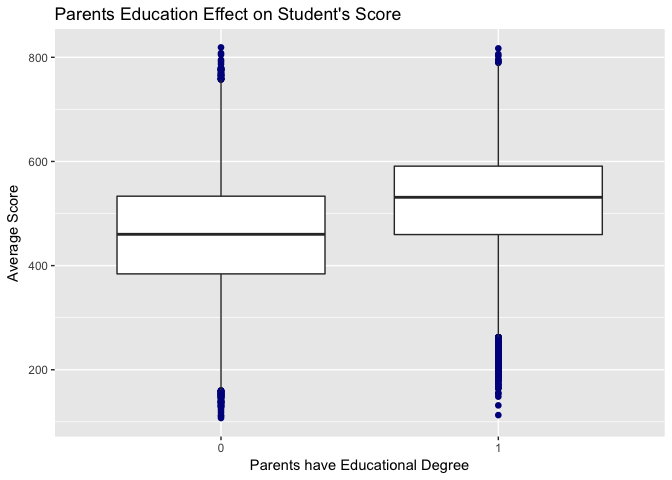

```r
ggplot(pedu_stscore, aes(x = as.character(p_edu), y = score_avg)) +
  geom_boxplot(outlier.colour="darkblue", outlier.shape=16, outlier.size=2, notch=FALSE) +
  xlab("Parents have Educational Degree") +
  ylab("Average Score") +
  ggtitle("Parents Education Effect on Student's Score")
```

```r
hchart(density(st_edu$score), name=list("Parents have Educational Degree")) %>%
  hc_add_series(density(st_non$score), name=list("Parents haven't Educational Degree"))
```

[interactive chart not shown]

۳. امکانات رفاهی در خانه موجب پیشرفت تحصیلی می گردد.  
در این سوال از تست یک طرفه ی ANOVA بهره برده ایم و با توجه به نتیجه ی بدست آمده گزاره ی فوق رد نخواهدشد و طبق تصویرسازی میانگین بالاتری در سطح امتیاز دانش آموزان با امکانات مشاهده می شود. پس باتوجه به تست برابری ردشده و تفاوت در عملکرد این سه دسته وجود دارد.

```r
bsg %>%
  select(idstud, idschool, idcntry, h_rs = bsdgher, contains("bsmmat"), contains("bsssci")) %>%
  mutate(score_avg = rowMeans(.[, 5:13])) %>%
  select(idstud, idschool, idcntry, h_rs, score_avg) %>%
  filter(!is.na(h_rs))-> rs_score

aov(score_avg~h_rs, data = rs_score) -> out
summary(out)
```

```
                Df    Sum Sq   Mean Sq F value Pr(>F)
h_rs             1 4.532e+08 453247857   50390 <2e-16 ***
Residuals   274774 2.472e+09      8995
---
Signif. codes:  0 '***' 0.001 '**' 0.01 '*' 0.05 '.' 0.1 ' ' 1
```

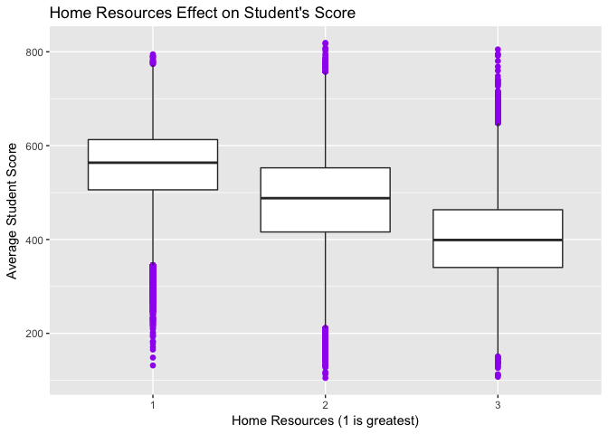

```r
ggplot(rs_score, aes(x = as.character(h_rs), y = score_avg)) +
  geom_boxplot(outlier.colour="purple", outlier.shape=16, outlier.size=2, notch=FALSE) +
  xlab("Home Resources (1 is greatest)") +
  ylab("Average Student Score") +
  ggtitle("Home Resources Effect on Student's Score")
```

```r
hchart(density(filter(rs_score, h_rs == 1)$score_avg), name=list("Many Resources")) %>%
  hc_add_series(density(filter(rs_score, h_rs == 2)$score_avg), name=list("Some Resources")) %>%
  hc_add_series(density(filter(rs_score, h_rs == 3)$score_avg), name=list("Few Resources"))
```

[interactive chart not shown]

۴. محیط آرام مدرسه نقش مهمی در پیشرفت تحصیلی دارد.

۵. معلمان با تحصیلات بالاتر یا تجربه بیشتر دانش آموزان موفق تری تربیت می کنند.  
جواب: طبق نتایج بدست آمده از آزمون t.test معلمانی که تحصیلات دانشگاهی دارند دانش آموزان قوی تری را پرورش میدهند.

```r
bst %>%
  select(idschool, idcntry, idteach, idstud, contains("bsmmat"), contains("bsssci")) %>%
  mutate(score_avg = rowMeans(.[, 5:13])) %>%
  select(idschool, idcntry, idteach, idstud, score_avg) -> st_stat


btm %>%
  select(idschool, idcntry, idteach, t_edu = btbg04) %>%
  filter(!is.na(t_edu)) -> t_stat

t_st <- merge(t_stat, st_stat)

t_st %>%
  mutate(t_edu = ifelse(t_edu > 4, 1, 0)) -> t_st_2lvl

t.test(score_avg ~ t_edu, data = t_st_2lvl, alt = "less")
```

```
    Welch Two Sample t-test

data:  score_avg by t_edu
t = -112.33, df = 35384, p-value < 2.2e-16
alternative hypothesis: true difference in means is less than 0
95 percent confidence interval:
     -Inf -68.1748
sample estimates:
mean in group 0 mean in group 1
       424.1092        493.2971
```

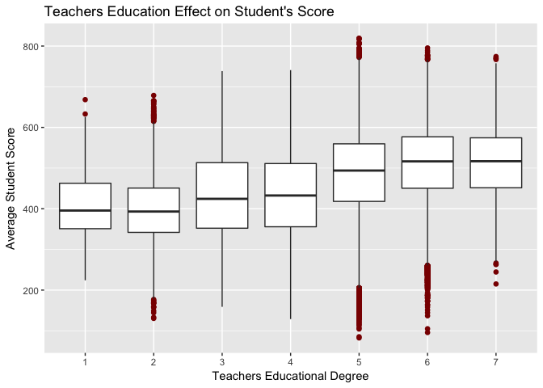

```r
ggplot(t_st, aes(x = as.character(t_edu), y = score_avg)) +
  geom_boxplot(outlier.colour="darkred", outlier.shape=16, outlier.size=2, notch=FALSE) +
  xlab("Teachers Educational Degree") +
  ylab("Average Student Score") +
  ggtitle("Teachers Education Effect on Student's Score")
```

```r
hchart(density(filter(t_st, t_edu == 1)$score_avg), name=list("Did not complete Upper secondary")) %>%
  hc_add_series(density(filter(t_st, t_edu == 2)$score_avg), name=list("Upper secondary")) %>%
  hc_add_series(density(filter(t_st, t_edu == 3)$score_avg), name=list("Post-secondary, non-tertiary")) %>%
  hc_add_series(density(filter(t_st, t_edu == 4)$score_avg), name=list("Short-cycle tertiary")) %>%
  hc_add_series(density(filter(t_st, t_edu == 5)$score_avg), name=list("Bachelor’s or equivalent")) %>%
  hc_add_series(density(filter(t_st, t_edu == 6)$score_avg), name=list("Master’s or equivalent")) %>%
  hc_add_series(density(filter(t_st, t_edu == 7)$score_avg), name=list("Doctor or equivalent"))
```

[interactive chart not shown]

۶. پسران در کاربرد هندسه قوی تر هستند.  
جواب: در این سوال از t.test استفاده شده است که بیشتربودن میانگین پسرها را مورد بررسی قرارمی دهد و نتیجه دال بر ناصحیح بودن این گذاره است و طبق تصویرسازی تقریبا عملکرد مشابهی دارند.

```r
bsg %>%
  select(idschool, idcntry, idstud, itsex, contains("bsmgeo")) %>%
  mutate(score_avg = rowMeans(.[, 5:9])) %>%
  select(idschool, idcntry, idstud, itsex, score_avg) -> geo_sex

t.test(score_avg ~ itsex, data = geo_sex, alt = "greater")
```

```
    Welch Two Sample t-test

data:  score_avg by itsex
t = 9.2376, df = 279150, p-value < 2.2e-16
alternative hypothesis: true difference in means is greater than 0
95 percent confidence interval:
 3.13238     Inf
sample estimates:
mean in group 1 mean in group 2
       474.3713        470.5604
```

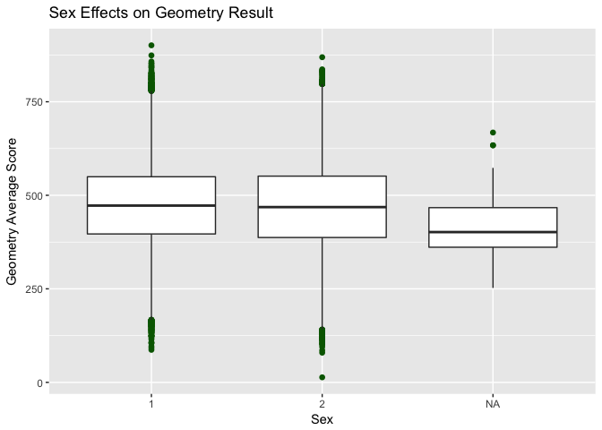

```r
ggplot(geo_sex, aes(x = as.character(itsex), y = score_avg)) +
  geom_boxplot(outlier.colour="darkgreen", outlier.shape=16, outlier.size=2, notch=FALSE) +
  xlab("Sex") +
  ylab("Geometry Average Score") +
  ggtitle("Sex Effects on Geometry Result")
```

```r
hchart(density(filter(geo_sex, itsex == 1)$score_avg), name=list("Female")) %>%
  hc_add_series(density(filter(geo_sex, itsex == 2)$score_avg), name=list("Male"))
```

[interactive chart not shown]

۷. تغذیه دانش آموزان نقش اساسی در یادگیری آنها دارد.  
جواب: اطلاع از وضعیت تغذیه را از میزان خوردن صبحانه ارزیابی شده است و از آزمون t.test برای ارزیابی این دو گروه استفاده شده است. کسانی که غالبن صبحانه می خورند در یک گروه و کسانی که کمتر صبحانه می خورند در گروه دیگر قراردارند و طبق نتیجه ی بدست آمده از تست کسانی که صبحانه می خورند امتیاز بالاتری کسب می کرده اند.

```r
bsg %>%
  select(idschool, idcntry, idstud, bsbg12 , contains("bsmmat"), contains("bsssci")) %>%
  mutate(score_avg = rowMeans(.[, 5:14])) %>%
  select(idschool, idcntry, idstud, bsbg12, score_avg) -> breakfast_score

breakfast_score %>%
  mutate(food = ifelse(bsbg12< 3, 1 , 0)) %>%
  select(idschool, idcntry, idstud, food, score_avg) %>%
  filter(!is.na(food))-> food_score

t.test(score_avg ~ food, data = food_score, alt = "less")
```

```
    Welch Two Sample t-test

data:  score_avg by food
t = -68.606, df = 208420, p-value < 2.2e-16
alternative hypothesis: true difference in means is less than 0
95 percent confidence interval:
      -Inf -26.86324
sample estimates:
mean in group 0 mean in group 1
       462.1998        489.7229
```

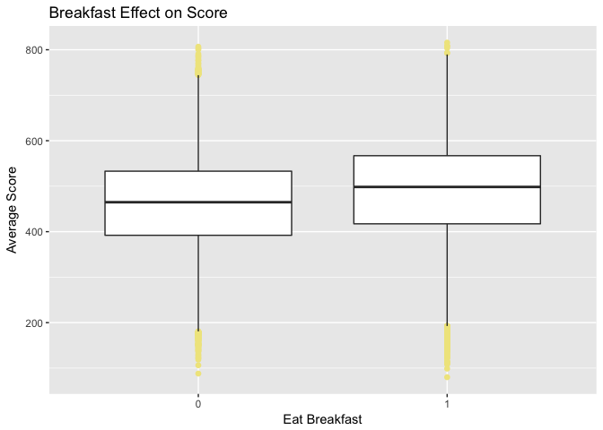

```r
ggplot(food_score, aes(x = as.character(food), y = score_avg)) +
  geom_boxplot(outlier.colour="khaki", outlier.shape=16, outlier.size=2, notch=FALSE) +
  xlab("Eat Breakfast") +
  ylab("Average Score") +
  ggtitle("Breakfast Effect on Score")
```

```r
hchart(density(filter(food_score, food == 0)$score_avg), name=list("Doesn't Eat Breakfast")) %>%
  hc_add_series(density(filter(food_score, food == 1)$score_avg), name=list("Eat Breakfast"))
```

[interactive chart not shown]

```r
bsg %>%
  select(idschool, idcntry, contains("bsmmat"), contains("bsssci")) %>%
  mutate(score_avg = rowMeans(.[, 3:12])) %>%
  group_by(idschool, idcntry) %>%
  summarise(score_avg_sc = mean(score_avg)) %>%
  select(idschool, idcntry, score_avg_sc) -> sc_score

bcg %>%
  select(idschool, idcntry, contains("bcbg13")) %>%
  mutate(rs_avg = ceiling(rowMeans(.[, 3:21]))) %>%
  select(idschool, idcntry, rs_avg) -> rs_sc

rs_sc_score <- merge(rs_sc, sc_score) %>%
  filter(!is.na(rs_avg))

summary(aov(score_avg_sc ~ rs_avg, data = rs_sc_score))
```

```
              Df   Sum Sq Mean Sq F value Pr(>F)
rs_avg         1  4368908 4368908   724.3 <2e-16 ***
Residuals   6971 42049368    6032
---
Signif. codes:  0 '***' 0.001 '**' 0.01 '*' 0.05 '.' 0.1 ' ' 1
```

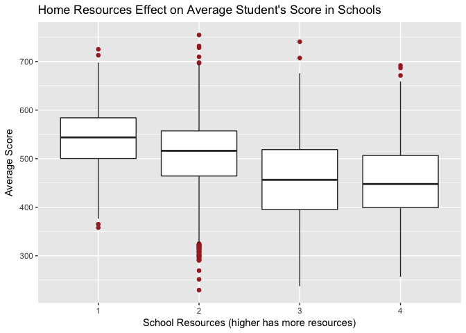

```r
ggplot(rs_sc_score, aes(x = as.character(rs_avg), y = score_avg_sc)) +
  geom_boxplot(outlier.colour="brown", outlier.shape=16, outlier.size=2, notch=FALSE) +
  xlab("School Resources (higher has more resources)") +
  ylab("Average Score") +
  ggtitle("Home Resources Effect on Average Student's Score in Schools")
```

```r
hchart(density(filter(rs_sc_score, rs_avg == 1)$score_avg), name=list("Not at all")) %>%
  hc_add_series(density(filter(rs_sc_score, rs_avg == 2)$score_avg), name=list("A little")) %>%
  hc_add_series(density(filter(rs_sc_score, rs_avg == 3)$score_avg), name=list("Some")) %>%
  hc_add_series(density(filter(rs_sc_score, rs_avg == 4)$score_avg), name=list("A lot"))
```

[interactive chart not shown]

۹. علت افت تحصیلی عدم مشارکت در کلاس است.  
در این سوال cor.test مورد ارزیابی قرارگرفته است بین حضور حداکثری و حداقلی در کلاس که نتیجه تاثیر منفی غیبت در کلاس در نتیجه ی آزمون است. در تصویرسازی ها از چهار دسته بندی میزان حضور در کلاس استفاده شده است.

```r
bsg %>%
  select(idschool, idcntry, idstud, bsbg11 , contains("bsmmat"), contains("bsssci")) %>%
  mutate(score_avg = rowMeans(.[, 5:14])) %>%
  select(idschool, idcntry, idstud, bsbg11, score_avg) %>%
  filter(!is.na(bsbg11))-> absent_score

absent_score %>%
  mutate(absence = ifelse(bsbg11< 3, 1 , 0)) %>%
  select(idschool, idcntry, idstud, absence, score_avg) -> absent_score_lvl2

cor.test(absent_score_lvl2$score_avg , absent_score_lvl2$absence, alternative = "less")
```

```
    Pearson's product-moment correlation

data:  absent_score_lvl2$score_avg and absent_score_lvl2$absence
t = -143.55, df = 264980, p-value < 2.2e-16
alternative hypothesis: true correlation is less than 0
95 percent confidence interval:
 -1.0000000 -0.2656555
sample estimates:
       cor
-0.2686229
```

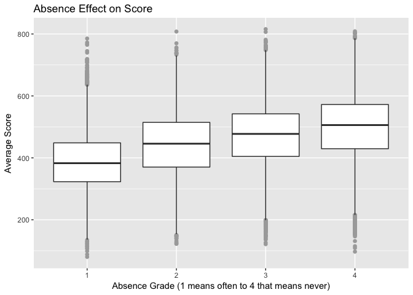

```r
ggplot(absent_score, aes(x = as.character(bsbg11), y = score_avg)) +
  geom_boxplot(outlier.colour="darkgray", outlier.shape=16, outlier.size=2, notch=FALSE) +
  xlab("Absence Grade (1 means often to 4 that means never)") +
  ylab("Average Score") +
  ggtitle("Absence Effect on Score")
```

```r
hchart(density(filter(absent_score, bsbg11 == 1)$score_avg), name=list("Once a week or more")) %>%
  hc_add_series(density(filter(absent_score, bsbg11 == 2)$score_avg), name=list("Once every two weeks")) %>%
  hc_add_series(density(filter(absent_score, bsbg11 == 3)$score_avg), name=list("Once a month")) %>%
  hc_add_series(density(filter(absent_score, bsbg11 == 4)$score_avg), name=list("Never or almost never"))
```

[interactive chart not shown]

۱۰. دانش آموزان ایرانی در استدلال قوی تر از کاربرد هستند.

سه گزاره جالب کشف کنید و ادعای خود را ثابت نمایید.

۱. دانش آموزانی که کنسول بازی دارند موفق تر نیستند.  
جواب: با توجه به نتیجه ی آزمون t.test این گذاره رد خواهد شد و با توجه به تصویرسازی ها کسانی که دستگاه بازی دارند موفق ترند.

```r
bsg %>%
  select(idstud, idschool, idcntry, g_s = bsbg06g, contains("bsmmat"), contains("bsssci")) %>%
  mutate(score_avg = rowMeans(.[, 5:13])) %>%
  select(idstud, idschool, idcntry, g_s, score_avg) %>%
  filter(!is.na(g_s))-> gs_score

t.test(score_avg ~ g_s, data = gs_score, alt = "greater")
```

```
    Welch Two Sample t-test

data:  score_avg by g_s
t = 56.052, df = 204350, p-value < 2.2e-16
alternative hypothesis: true difference in means is greater than 0
95 percent confidence interval:
 22.39712      Inf
sample estimates:
mean in group 1 mean in group 2
       489.2715        466.1973
```

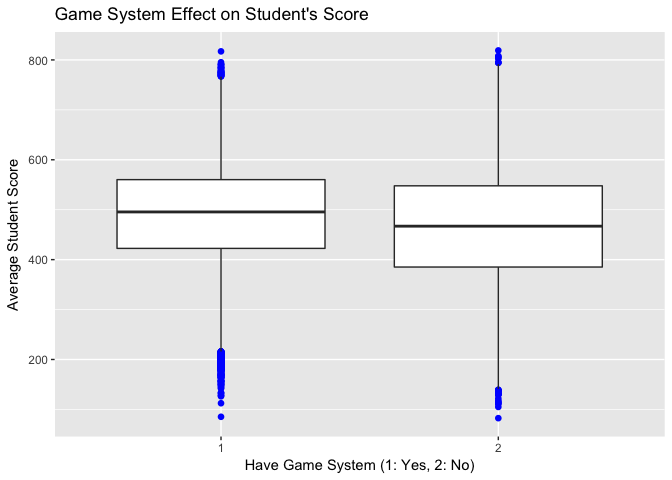

```r
ggplot(gs_score, aes(x = as.character(g_s), y = score_avg)) +
  geom_boxplot(outlier.colour="blue", outlier.shape=16, outlier.size=2, notch=FALSE) +
  xlab("Have Game System (1: Yes, 2: No)") +
  ylab("Average Student Score") +
  ggtitle("Game System Effect on Student's Score")
```

```r
hchart(density(filter(gs_score, g_s == 2)$score_avg), name=list("Doesn't Have Game System")) %>%
  hc_add_series(density(filter(gs_score, g_s == 1)$score_avg), name=list("Has Game System"))
```

[interactive chart not shown]

۲. دانش آموزانی که گوشی موبایل شخصی ندارند موفق تر نیستند.  
جواب: با توجه به نتیجه ی آزمون t.test دانش آموزانی که تلفن همراه شخصی دارند موفق تر هستند و فرض سوال رد می شود.

```r
bsg %>%
  select(idstud, idschool, idcntry, sm = bsbg06f, contains("bsmmat"), contains("bsssci")) %>%
  mutate(score_avg = rowMeans(.[, 5:13])) %>%
  select(idstud, idschool, idcntry, sm, score_avg) %>%
  filter(!is.na(sm))-> sm_score

t.test(score_avg ~ sm, data = sm_score, alt = "greater")
```

```
    Welch Two Sample t-test

data:  score_avg by sm
t = 55.599, df = 72985, p-value < 2.2e-16
alternative hypothesis: true difference in means is greater than 0
95 percent confidence interval:
 28.03115      Inf
sample estimates:
mean in group 1 mean in group 2
       485.5480        456.6623
```

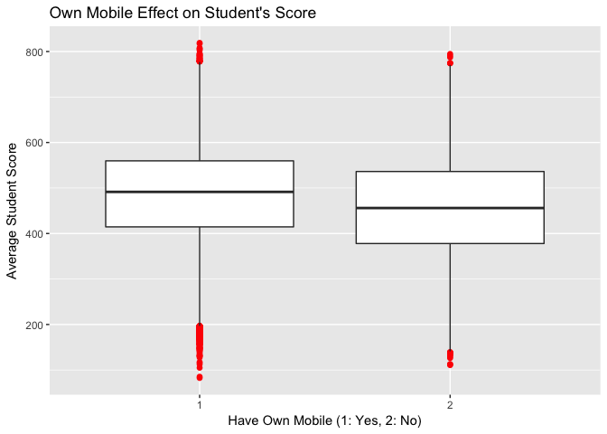

```r
ggplot(sm_score, aes(x = as.character(sm), y = score_avg)) +
  geom_boxplot(outlier.colour="red", outlier.shape=16, outlier.size=2, notch=FALSE) +
  xlab("Have Own Mobile (1: Yes, 2: No)") +
  ylab("Average Student Score") +
  ggtitle("Own Mobile Effect on Student's Score")
```

```r
hchart(density(filter(sm_score, sm == 2)$score_avg), name=list("Doesn't Have Own Mobile")) %>%
  hc_add_series(density(filter(sm_score, sm == 1)$score_avg), name=list("Has Own Mobile"))
```

[interactive chart not shown]

***

۳. علاقه به مدرسه با نتیجه ی دانش آموز در امتحان رابطه دارد  
جواب: با توجه به نتیجه ی آزمون ANOVA دانش اموزان به نسبت میزان علاقه ای که به رفتن به مدرسه نشان می دهند تا میزان علاقه به دیدن دوستانشان به صورت میانگین از نتایج بهتری برخوردارند و فرض برابری این دسته ها که از ۱ که به معنی علاقه مندترین است تا ۴ رد می شود.

```r
bsg %>%
  select(idstud, idschool, idcntry, contains("bsmmat"), contains("bsssci"), contains("bsbg15")) %>%
  mutate(score_avg = rowMeans(.[, 4:13]), lv_sc = floor(rowMeans(.[, 14:20]))) %>%
  select(idstud, idschool, idcntry, score_avg, lv_sc) %>%
  filter(!is.na(lv_sc)) -> sl_score

summary(aov(score_avg ~ lv_sc, data = sl_score))
```

```
                Df    Sum Sq Mean Sq F value Pr(>F)
lv_sc            1 7.440e+06 7440088   721.7 <2e-16 ***
Residuals   265232 2.734e+09   10309
---
Signif. codes:  0 '***' 0.001 '**' 0.01 '*' 0.05 '.' 0.1 ' ' 1
```

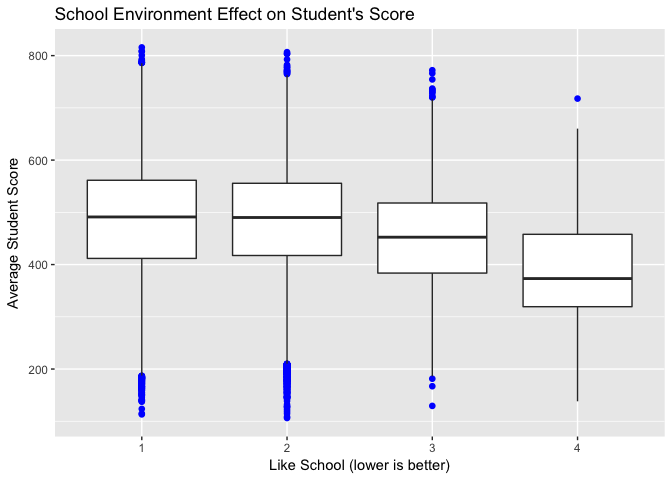

```r
ggplot(sl_score, aes(x = as.character(lv_sc), y = score_avg)) +
  geom_boxplot(outlier.colour="blue", outlier.shape=16, outlier.size=2, notch=FALSE) +
  xlab("Like School (lower is better)") +
  ylab("Average Student Score") +
  ggtitle("School Environment Effect on Student's Score")
```

```r
hchart(density(filter(sl_score, lv_sc == 1)$score_avg), name=list("Agree a lot")) %>%
  hc_add_series(density(filter(sl_score, lv_sc == 2)$score_avg), name=list("Agree a little")) %>%
    hc_add_series(density(filter(sl_score, lv_sc == 3)$score_avg), name=list("Disagree a little")) %>%
    hc_add_series(density(filter(sl_score, lv_sc == 4)$score_avg), name=list("Disagree a lot"))
```

[interactive chart not shown]